# Session 2 - Customising Functions

4 December 2015

## Digging Deeper

R comes with numerous in-built datasets

```r
?ToothGrowth
```

Here, the length of growing teeth has been measured using:

- 2 Vitamin C Supplements (Orange Juice or Ascorbic Acid)
- 3 different dose levels (0.5, 1.0 & 2.0mg)

## Tooth Growth

First let's

1. make a shortcut to this dataset called `tg`
2. change the dose levels to a categorical variable (i.e a `factor`)

```r
tg <- ToothGrowth
tg$dose <- factor(tg$dose)
levels(tg$dose) <- c("Low", "Med", "High")
```

## Data Inspection

Firstly we should inspect and plot our data

```r
head(tg)
```

```
##    len supp dose
## 1  4.2   VC  Low
## 2 11.5   VC  Low
## 3  7.3   VC  Low
## 4  5.8   VC  Low
## 5  6.4   VC  Low
## 6 10.0   VC  Low
```

## Data Inspection

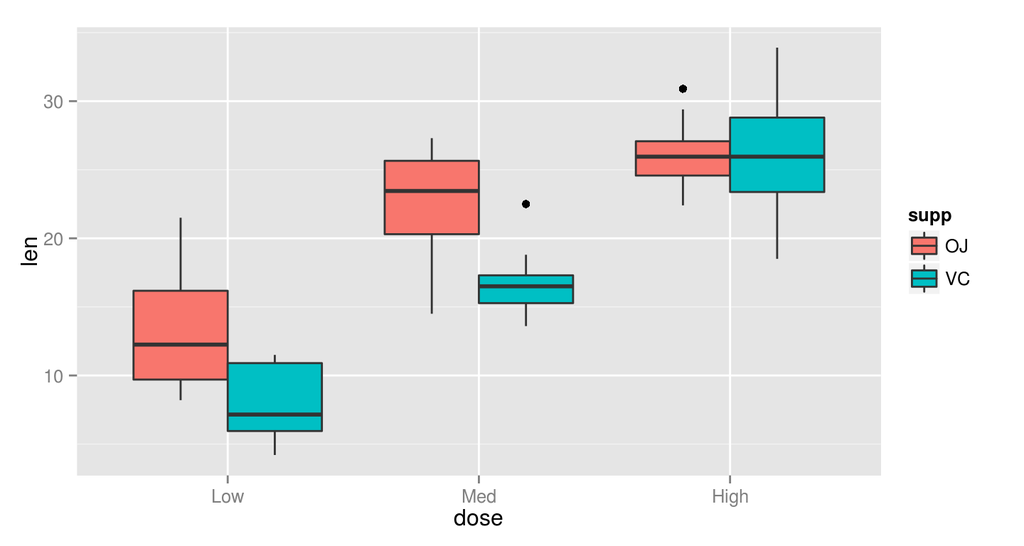

```r
library(ggplot2)
ggplot(tg, aes(x = dose, y = len, fill = supp)) +
  geom_boxplot()
```

## Tooth Growth

Our task is to conduct a `t.test()` for each dose level to see if there is any effect on tooth length.

Let's try it for the low dosage level

```r
t.test(len ~ supp, data = tg, subset = dose == "Low")
```

```
##
##  Welch Two Sample t-test
##
## data:  len by supp
## t = 3.1697, df = 14.969, p-value = 0.006359
## alternative hypothesis: true difference in means is not equal to 0
## 95 percent confidence interval:
##  1.719057 8.780943
## sample estimates:
## mean in group OJ mean in group VC
##            13.23             7.98
```

## Tooth Growth

- Doing this for all 3 levels will look messy!
- Let's change the structure of the output to make it look nicer
- First, how does R really save the results from the `t.test()` function?

```r
results <- t.test(len ~ supp, data = tg, subset = dose == "Low")
str(results)
```

[output not shown]

## Tooth Growth

This is an *R* object type called a `list`

*What are we really interested in?*

## Tooth Growth

This is an *R* object type called a `list`

*What are we really interested in?*

1. The difference in means?
2. The *T*-statistic
3. The degrees of freedom
4. The *p*-value

**Where are these values in the function output?**

## Tooth Growth

We could write a function to output these as a `data.frame`

```r
myToothTest <- function(data){

  # Perform the t.test
  res <- t.test(len~supp, data)

  # Output the data.frame
  data.frame(Difference  = -diff(res$estimate),
             T = res$statistic,
             DF = res$parameter,
             P = res$p.value,
             row.names= NULL)

}
```

## Tooth Growth

- Now we can run the function
- Note that we're going to do the sub-setting first

```r
subTg <- subset(tg, dose == "Low")
myToothTest(subTg)
```

```
##   Difference        T       DF           P
## 1       5.25 3.169733 14.96875 0.006358607
```

- This looks much nicer!

## Tooth Growth

- Let's incorporate the sub-setting into the function
- AND add the dose level to the output

## Tooth Growth

```r
myToothTest <- function(doseLevel, data){

  stopifnot(doseLevel %in% levels(data$dose))
  data <- subset(data, dose == doseLevel)

  # Perform the t.test
  res <- t.test(len~supp, data)

  # Output the data.frame
  data.frame(Dose = doseLevel,
             Difference  = -diff(res$estimate),
             T = res$statistic,
             DF = res$parameter,
             P = res$p.value,
             row.names= NULL)

}
```

## Tooth Growth

Now the function is even easier to run

```r
myToothTest("Low", tg)
```

```
##   Dose Difference        T       DF           P
## 1  Low       5.25 3.169733 14.96875 0.006358607
```

## Now the FUN starts

*R* has a function called `lapply()`

This will apply a function to each element of a vector

```r
?lapply
```

Just to see this in action:

```r
y <- c(1, 16, 2, 9)
lapply(y, FUN = sqrt)
```

[output not shown]

**This places each element in the FIRST argument position of the function**

## Now the FUN starts

There is a alternate function `sapply()` that simplifies the output where possible

```r
sapply(y, FUN = sqrt)
```

```
## [1] 1.000000 4.000000 1.414214 3.000000
```

It's very useful, but slightly unpredictable…

## Now the FUN starts

*Can we use this idea for our different dose levels?*

## Now the FUN starts

*Can we use this idea for our different dose levels?*

YES!!!

This is why I placed `doseLevels` as the first argument of our function

```r
doseLevels <- levels(tg$dose)
lapply(doseLevels, myToothTest, data = tg)
```

[output not shown]

Note that we specified `data = tg` after the function call

## Getting amazing looking output

The *R* package `dplyr` has a function `bind_rows()` for joining identical `data.frame` objects.

First install and/or load the package

```r
install.packages(dplyr)
library(dplyr)
```

## Getting amazing looking output

```r
doseResults <- lapply(doseLevels, myToothTest, data = tg)
doseResults <- bind_rows(doseResults)
doseResults
```

```
## Source: local data frame [3 x 5]
##
##    Dose Difference          T       DF           P
##   (chr)      (dbl)      (dbl)    (dbl)       (dbl)
## 1   Low       5.25  3.1697328 14.96875 0.006358607
## 2   Med       5.93  4.0327696 15.35767 0.001038376
## 3  High      -0.08 -0.0461361 14.03982 0.963851589
```

## Getting amazing looking output

- And for those using R Markdown/knitr

```r
library(knitr)
kable(doseResults)
```

| Dose | Difference | T | DF | P |
| --- | --- | --- | --- | --- |
| Low | 5.25 | 3.1697328 | 14.96875 | 0.0063586 |
| Med | 5.93 | 4.0327696 | 15.35767 | 0.0010384 |
| High | -0.08 | -0.0461361 | 14.03982 | 0.9638516 |

## In the real world

This technique can be applied to numerous datasets

- You might want to do linear regression on data from different climates/regions
- You might have thousands of SNPs to run a `fisher.test()` on